# Irreproducible discovery rate

Author

[Michael Love](http://mikelove.github.io)

We’ve discussed the false discovery rate and the local false discovery rate, which both involve the assumption of two groups of hypotheses in the data: a set of null hypotheses, and a set of alternative hypotheses. Here, I’d like to introduce a slightly different framework for assigning probabilities to high-throughput data, which is called the *irreproducible discovery rate*, or IDR. A reference for the IDR is the article [Measuring reproducibility of high-throughput experiments](https://arxiv.org/abs/1110.4705) by Qunhua Li, James B. Brown, Haiyan Huang, and Peter J. Bickel.

Imagine we have two replicates for a high-throughput experiment, each which produce some kind of score for many thousands of locations in the genome, where higher scores are the interesting locations. Rather than trying to define what constitutes a null distribution of scores, we ask a different question: what is the probability that, when we see a high score for one experiment, we would see a low score for a replicated experiment? We want a set of locations where the scores are high and reproducibly so, or at least to define how often we would not see reproducibly high scores. We will see what this looks like in practice, using ChIP-seq data, which is the kind of dataset that the method was designed to help with.

# ChIP-seq

[ChIP-seq](https://en.wikipedia.org/wiki/ChIP-sequencing) is an experiment to determine the location of proteins bound to DNA along the genome. After aligning the sequenced reads to the genome, there are numerous software for defining the discrete regions, called “peaks”, where the sequenced reads stack up, which would indicate a location where protein was frequently bound to DNA, looking across the many cells that are pooled to perform a ChIP-seq experiment. Each peak can be given a “score” as to how certain we are that a protein may have been bound there, which relates to the number of reads that stack up in the peak, and also takes into account the “background” of reads. Typically, a control experiment is performed without a specific antibody, and the number of reads for the ChIP experiment is compared relative to the number of reads for the control experiment.

The [ENCODE project](https://www.encodeproject.org/) produced many ChIP-seq experiments for various proteins and across many cell lines. We will focus on a specific experiment which is listed [here](https://www.encodeproject.org/experiments/ENCSR841NDX/). This specific experiment is called “ELF1 ChIP-seq on human GM12878 (immortalized cell line)”, which means that the protein of interest was ELF1, and the experiment was performed on the GM12878 cell line. We download two files: narrowPeak BED files indicating the peaks for the two replicates of the experiment. The narrowPeak BED format is described [here](https://genome.ucsc.edu/FAQ/FAQformat.html#format12), but the important thing for our purposes is that the first three columns indicate the chromosome, start and end of the peak, and the seventh column has the score for the peak. We download these compressed narrowPeak BED files with the following code:

```r
url1 <- "https://www.encodeproject.org/files/ENCFF003ZKO/@@download/ENCFF003ZKO.bed.gz"
file1 <- "peaks_rep1.bed.gz"
if (!file.exists(file1)) download.file(url1, file1)
url2 <- "https://www.encodeproject.org/files/ENCFF093VDW/@@download/ENCFF093VDW.bed.gz"
file2 <- "peaks_rep2.bed.gz"
if (!file.exists(file2)) download.file(url2, file2)
```

We then read in these narrowPeak BED files using `read_delim`, and then construct GRanges objects for each replicate. Finally, we subset to just the standard chromosomes (chr1-chr22,chrX,chrY,chrM).

```r
library(readr)
library(GenomicRanges)
df1 <- read_delim(file1, delim="\t", col_names=FALSE)
df2 <- read_delim(file2, delim="\t", col_names=FALSE)
peak1 <- GRanges(df1$X1, IRanges(df1$X2, df1$X3), score=df1$X7)
peak2 <- GRanges(df2$X1, IRanges(df2$X2, df2$X3), score=df2$X7)
peak1 <- GenomeInfoDb::keepStandardChromosomes(peak1, pruning.mode="coarse")
peak2 <- GenomeInfoDb::keepStandardChromosomes(peak2, pruning.mode="coarse")
```

In order to determine the irreproducible discovery rate, we need to first identify the set of peaks that are overlapping in the two experiments. To do this, we use the `findOverlap` function.

```r
fo <- findOverlaps(peak1, peak2)
length(peak1)
```

```
[1] 299686
```

```r
length(peak2)
```

```
[1] 299702
```

```r
length(fo)
```

```
[1] 113096
```

Many of the peaks in one replicate do not overlap a peak in the other experiment. Additionally, there are a number of peaks in one experiment which overlap more than one peak in the other experiment. Ideally, we would make a more complicated decision here, to merge the scores from the multiple overlapping peaks, but here, for demonstration of the method, we just remove these peaks with multiple overlaps.

```r
table(duplicated(from(fo)))
```

```
 FALSE   TRUE
103043  10053
```

```r
table(duplicated(to(fo)))
```

```
 FALSE   TRUE
104046   9050
```

```r
fo <- as.data.frame(fo)
fo <- fo[!duplicated(fo$queryHits) & !duplicated(fo$subjectHits),]
```

We now define two variables: the set of scores for the two replicates. Because we use `fo` to index the `score` column of the peaks, we know that `y1` and `y2` now contain the corresponding scores. On the raw score scale, we can see the overlapping peaks with the highest score are consistently high in both experiments.

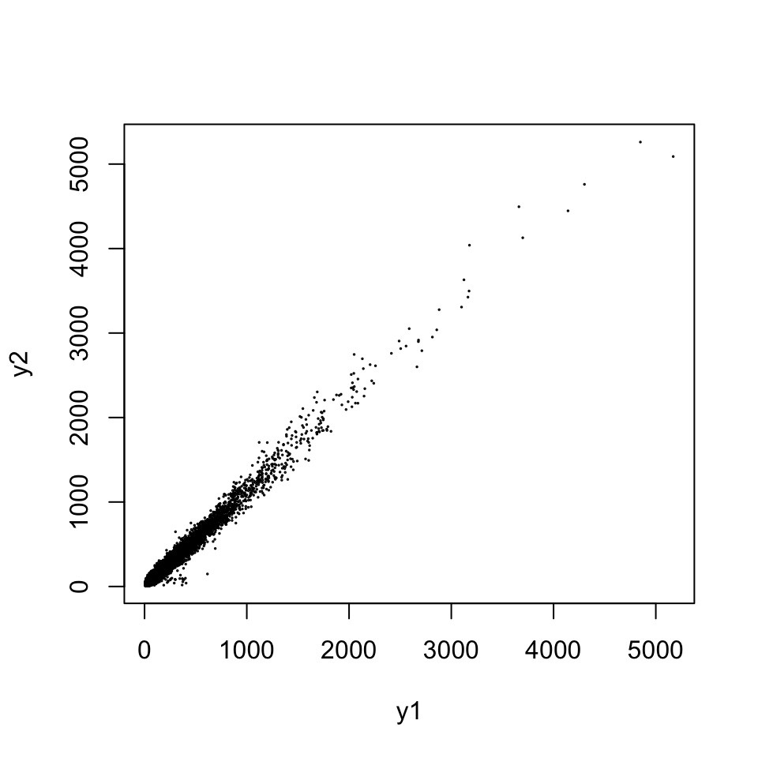

```r
y1 <- peak1$score[fo[,1]]
y2 <- peak2$score[fo[,2]]
plot(y1, y2, cex=.1)
```

On the log scale, we can see that the consistency falls off as the scores get lower:

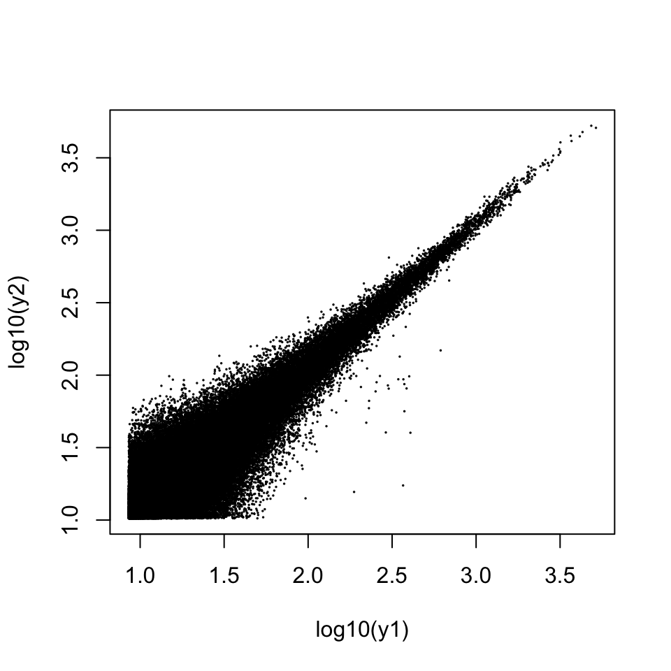

```r
plot(log10(y1), log10(y2), cex=.1)
```

Finally, plotting the ranks (highest to lowest), we can see much more clearly how the consistency falls off after around 20,000 peaks. For example, note that there are peaks ranked within the top 20,000 for one experiment, which are ranked lowest for the replicate experiment.

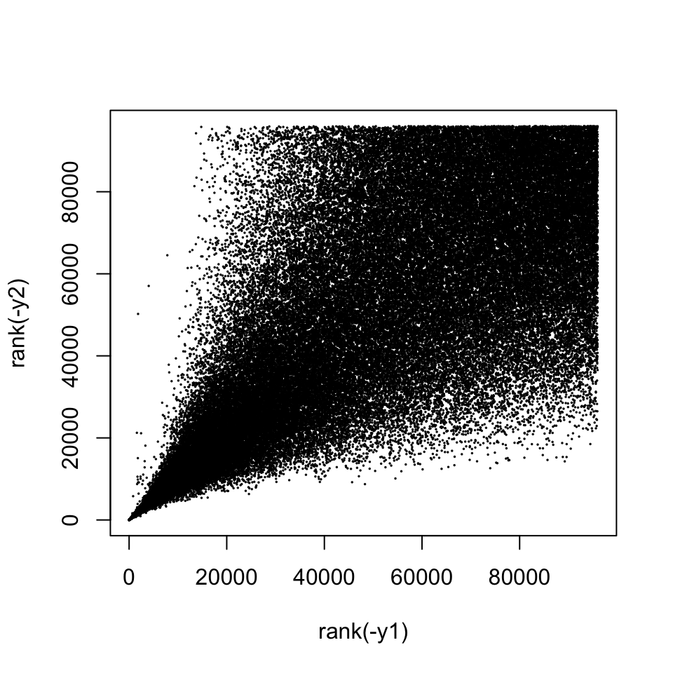

```r
plot(rank(-y1), rank(-y2), cex=.1)
```

We use the `idr` package to estimate the IDR for these replicates. Note that the IDR package authors now maintain IDR as a [python package](https://github.com/nboley/idr). The python package is reported to be faster than the R package.

From exploring use of the R package, I noticed it required that the scores be log transformed. Here we subset to just 5,000 randomly sampled peaks to demonstrate use of the package. Finally, we combine the results and original data into a data.frame `df`.

```r
library(idr)
dat <- cbind(log10(y1), log10(y2))
dat <- dat[sample(nrow(dat),5000),]
system.time({
  res <- est.IDR(dat, mu=3, sigma=1, rho=.9, p=.5)
})
```

```
   user  system elapsed
  1.056   0.009   1.066
```

```r
df <- data.frame(rep1=dat[,1],rep2=dat[,2],
                 rank1=rank(-dat[,1]),rank2=rank(-dat[,2]),
                 idr=res$idr)
```

We can plot the log scores for the two replicates and indicate the estimated IDR using ggplot2.

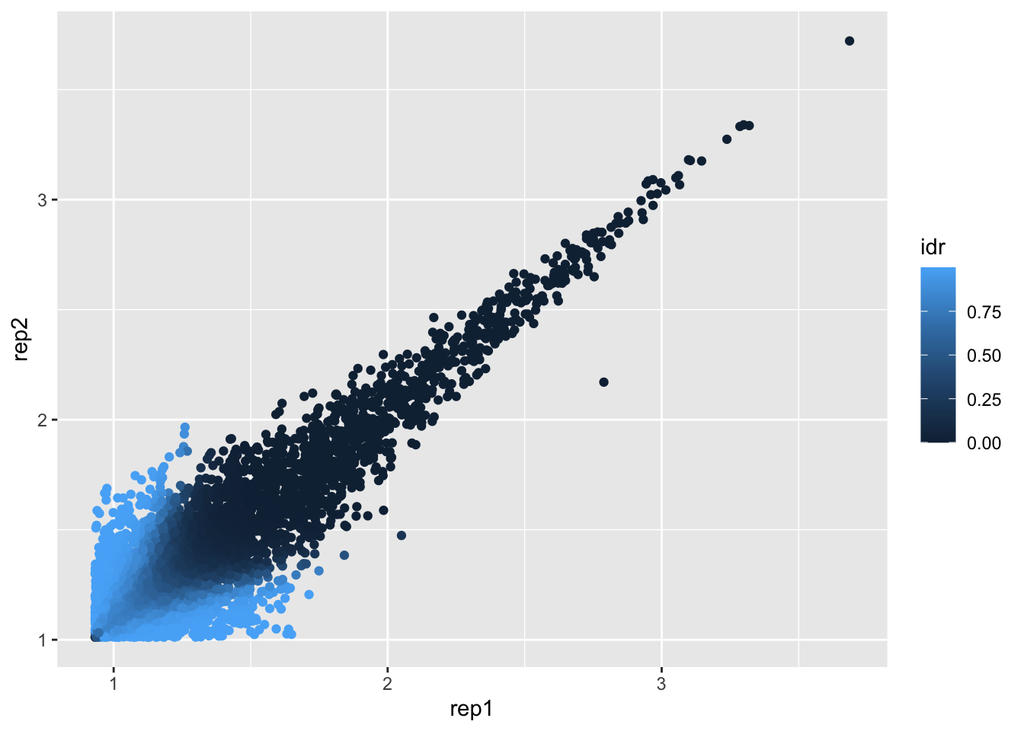

```r
library(ggplot2)
ggplot(df, aes(rep1,rep2,col=idr)) + geom_point()
```

Again, plotting the IDR, now with the ranks for the two replicates. Note how the IDR increases in the zones where a high score for one replicate is associated with a low score for the other replicate.

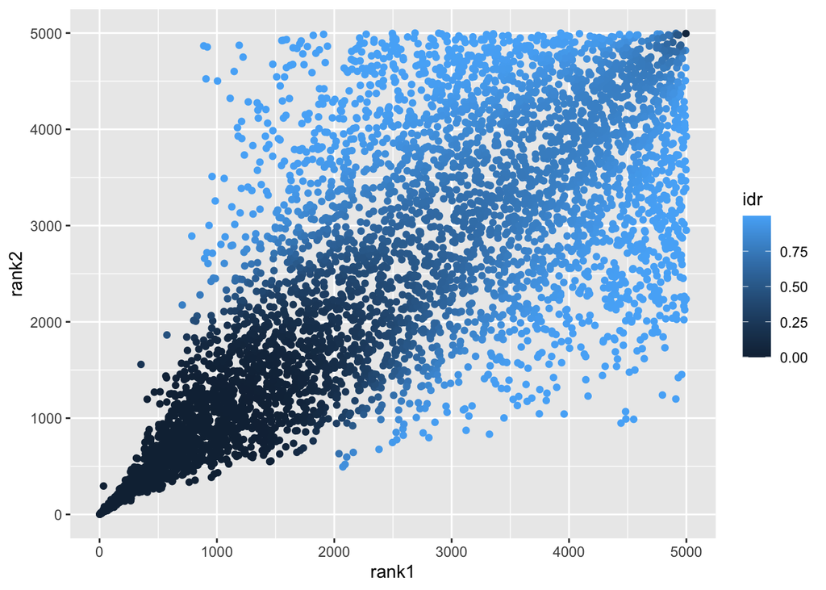

```r
ggplot(df, aes(rank1,rank2,col=idr)) + geom_point()
```